# chapter6

kiirasar

2022-12-05

```r
date()
```

```
## [1] "Tue Dec 13 06:30:26 2022"
```

# Assignment 6: Tasks and Instructions

## Data wrangling **(max 5 points)**

See meet_and_repeat.R.

## Analysis **(max 15 points)**

- Use the corresponding **Exercise Set** and the **MABS4IODS** materials
- **Note.** As you read the data sets in your **chapter6.Rmd** you may have to factor the **categorical variables** again, as R may not recognise them automatically as factors.
- **Note.** that you must SWAP the data sets! :) It is NOT a simple copy & paste of the MABS book!

```r
#install.packages('ggplot2')
library(dplyr)
library(tidyr)
library(ggplot2)
```

## RATS data and Chapter8 **(0-7 points)**

Implement the analyses of **Chapter 8** of MABS using the **RATS data.**

- 0-4 points for graphs or analysis results
- 0-3 points for their interpretations

**Download and convert the data to long form**

```r
RATS3 <- read.table("https://raw.githubusercontent.com/KimmoVehkalahti/MABS/master/Examples/data/rats.txt", header = TRUE, sep = '\t')
RATS3$ID <- factor(RATS3$ID) #change these to factors
RATS3$Group <- factor(RATS3$Group) #change these to factors

RATSL3 <-  pivot_longer(RATS3, cols = -c(ID, Group),
                       names_to = "WD", values_to = "Weight") %>%
  mutate(Time3 = as.integer(substr(WD,3,4))) %>%
  arrange(Time3) #change it to long-form

glimpse(RATSL3) #sanity-check
```

```
## Rows: 176
## Columns: 5
## $ ID     <fct> 1, 2, 3, 4, 5, 6, 7, 8, 9, 10, 11, 12, 13, 14, 15, 16, 1, 2, 3,…
## $ Group  <fct> 1, 1, 1, 1, 1, 1, 1, 1, 2, 2, 2, 2, 3, 3, 3, 3, 1, 1, 1, 1, 1, …
## $ WD     <chr> "WD1", "WD1", "WD1", "WD1", "WD1", "WD1", "WD1", "WD1", "WD1", …
## $ Weight <int> 240, 225, 245, 260, 255, 260, 275, 245, 410, 405, 445, 555, 470…
## $ Time3  <int> 1, 1, 1, 1, 1, 1, 1, 1, 1, 1, 1, 1, 1, 1, 1, 1, 8, 8, 8, 8, 8, …
```

### Summary RATS

```r
names(RATSL3) #"ID"     "Group"  "WD"     "Weight" "Time3"
```

```
## [1] "ID"     "Group"  "WD"     "Weight" "Time3"
```

```r
str(RATSL3) #176 observations and 5 columns (variables)
```

```
## tibble [176 × 5] (S3: tbl_df/tbl/data.frame)
##  $ ID    : Factor w/ 16 levels "1","2","3","4",..: 1 2 3 4 5 6 7 8 9 10 ...
##  $ Group : Factor w/ 3 levels "1","2","3": 1 1 1 1 1 1 1 1 2 2 ...
##  $ WD    : chr [1:176] "WD1" "WD1" "WD1" "WD1" ...
##  $ Weight: int [1:176] 240 225 245 260 255 260 275 245 410 405 ...
##  $ Time3 : int [1:176] 1 1 1 1 1 1 1 1 1 1 ...
```

```r
summary(RATSL3) #ID and Group factors, WD chr and Weight and Time3 int
```

```
##        ID      Group       WD                Weight          Time3
##  1      : 11   1:88   Length:176         Min.   :225.0   Min.   : 1.00
##  2      : 11   2:44   Class :character   1st Qu.:267.0   1st Qu.:15.00
##  3      : 11   3:44   Mode  :character   Median :344.5   Median :36.00
##  4      : 11                             Mean   :384.5   Mean   :33.55
##  5      : 11                             3rd Qu.:511.2   3rd Qu.:50.00
##  6      : 11                             Max.   :628.0   Max.   :64.00
##  (Other):110
```

### Individuals on the plot

Graphical displays of individual datapoint: Weight values over time between 3 groups.

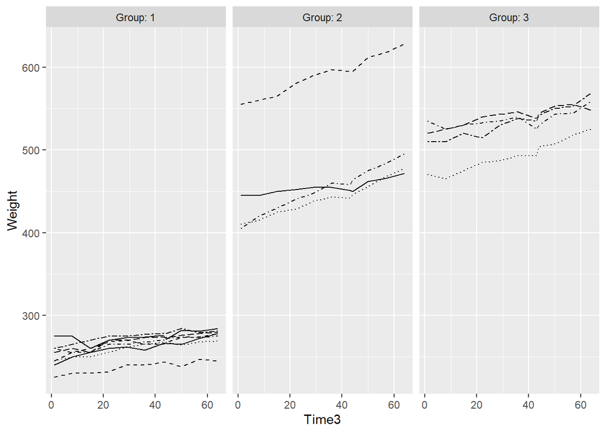

```r
library(dplyr); library(tidyr)
ggplot(RATSL3, aes(x = Time3, y = Weight, linetype = ID)) +
  geom_line() +
  scale_linetype_manual(values = rep(1:10, times=4)) +
  facet_grid(. ~ Group, labeller = label_both) +
  theme(legend.position = "none") +
  scale_y_continuous(limits = c(min(RATSL3$Weight), max(RATSL3$Weight)))
```

**Interpretation of the plot: Individual plot** - First, in almost every group the weight is increasing over time (but in group 1 it remains quite stable). - Second, Group 2 and 3 have higher weight than group 1 - Third, there is not much change in weight within the groups.